Case study · Remote sensing · Dhaka, Bangladesh

# Where Dhaka's heat sits, who lives in it, and what drives it

Five cloud-free Landsat 8/9 scenes from 2022 to 2026, 196 wards, WorldPop population, and a validation against air temperature. Every number below comes from the code in the repository.

Fahim AhmedUrban and Regional Planning, BUETgithub.com/fmad121581-hub/uhi-dhaka

**2.9 to 7.1 °C**Surface heat island intensity, urban core minus rural reference, across five dates

**40 to 56%**Of residents live where land surface temperature is at least one SD above the mean

**3 wards**In the hottest decile on every date, about 117,000 people, 91% built-up

**r = 0.97**Landsat surface temperature against air temperature (n = 5, small sample)

## The question

Planners in Dhaka talk about the urban heat island as one number. The surface does not behave that way. Intensity changes with the season, and the places that run hot are not always the places people expect. This project asks three things. How strong is the surface heat island and how much does it move over the year? Which wards stay hot regardless of date? And what do the people in them have in common on the ground?

Landsat Collection 2 Level-2 supplies surface temperature directly (band ST_B10), so no emissivity model of my own sits between the satellite and the result. Pixels are masked with the QA band, with a five-pixel buffer around clouds, and a scene is dropped if fewer than 60% of pixels inside the boundary are clear.

## Heat changes with the season

The urban core runs 2.9 °C warmer than the rural reference in the cool, dry February of 2022 and 7.1 °C warmer in early June 2026, just before the monsoon. Mid-monsoon cannot be measured at all. One July scene was 0% clear, which is itself a finding for anyone planning a monsoon-season study over Dhaka.

| Date | Clear % | Mean LST °C | SUHI °C | NDVI–LST r |
| --- | --- | --- | --- | --- |
| 2022-02-24 | 99 | 28.3 | 2.9 | -0.59 |
| 2025-05-07 | 87 | 35.6 | 4.7 | -0.62 |
| 2025-10-22 | 96 | 35.4 | 4.2 | -0.38 |
| 2026-02-19 | 95 | 30.1 | 4.5 | -0.65 |
| 2026-06-03 | 73 | 39.3 | 7.1 | -0.63 |

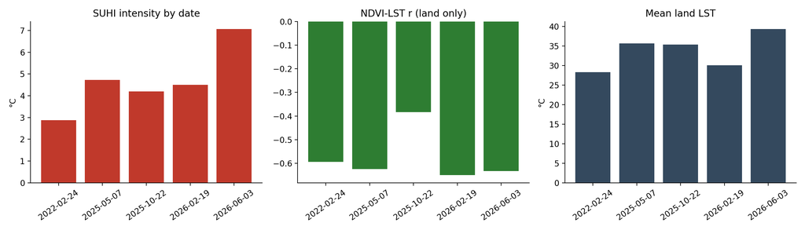

Surface heat island intensity, vegetation correlation and mean land temperature by date. Water is excluded from the correlation.

For the February 2022 scene the intensity is 2.87 °C with a 95% interval of 2.64 to 3.10, from a spatial block bootstrap with 3 km blocks so that neighbouring pixels are not treated as independent.

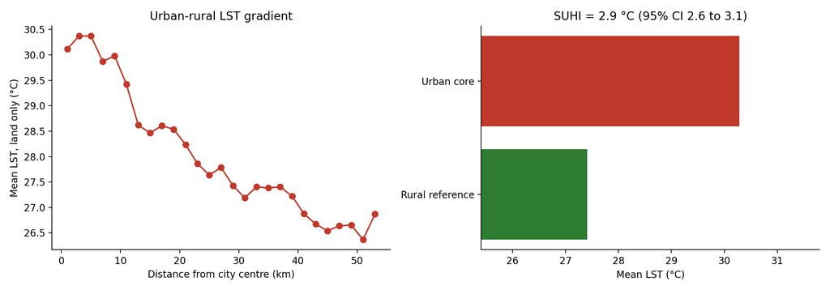

Land surface temperature against distance from the city centre, 24 February 2022.

## Hot wards cluster, and a few never cool down

Ward mean temperature is strongly clustered in space (Moran's I = 0.84 on the February 2022 scene). Getis-Ord Gi* flags 45 wards as hot spots and 45 as cold spots out of 196, and the remaining 106 are not significant. Ward rankings hold across seasons, with Spearman correlations of 0.74 to 0.89 between dates.

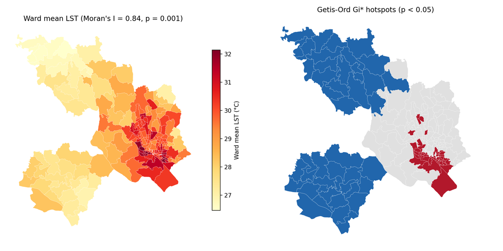

Ward hot and cold spots, 24 February 2022.

Three wards sit in the top decile on all five dates: Ward 90 in Shyampur, Ward 60 in Lalbagh, and Sultanganj in Kamrangirchar. Between them they hold about 117,000 people. Their mean built-up share is 90.9%, against 56.4% in the other wards.

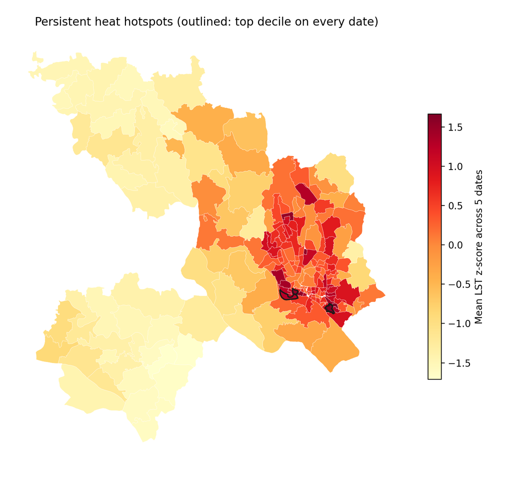

Mean temperature z-score across five dates. Outlined wards are in the top decile every time.

## What drives the pattern depends on the season

My first reading, from that single scene, was that distance from the centre matters most. Repeating the analysis on every date shows it does not hold everywhere. In the two February scenes distance from the centre leads. In May, October and June, the built-up share within 330 m leads, by a wide margin in October and June.

| Date | Exposed ≥ mean+1SD % | Hottest decile % | RF R² (spatial CV) | Top driver |
| --- | --- | --- | --- | --- |
| 2022-02-24 | 47.5 | 25.1 | 0.66 | distance to centre |
| 2025-05-07 | 39.9 | 23.0 | 0.63 | built-up 330 m |
| 2025-10-22 | 50.2 | 30.4 | 0.69 | built-up 330 m |
| 2026-02-19 | 49.5 | 23.3 | 0.70 | distance to centre |
| 2026-06-03 | 55.7 | 38.7 | 0.78 | built-up 330 m |

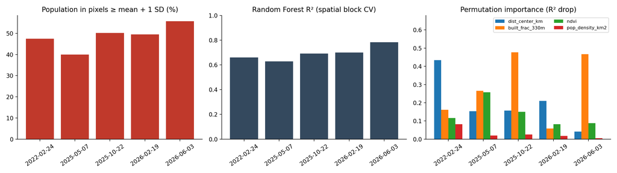

Population exposure, model skill and permutation importance on each date.

Between 40% and 56% of the study-area population lives in pixels at least one standard deviation above that date's mean temperature. The share in the hottest decile ranges from 23% to 39%, and it is highest in the early-June scene.

## Does satellite surface heat track the air people breathe?

Surface temperature is not air temperature, so I checked. For each of the five dates I took the mean Landsat temperature within 5 km of the Dhaka airport and compared it with ERA5-Land air temperature at the overpass time. The correlation is 0.97 (Spearman 0.90), and the surface runs 3 to 10 °C above the air, 6.5 °C on average. That gap is expected for dry, built-up ground in direct sun.

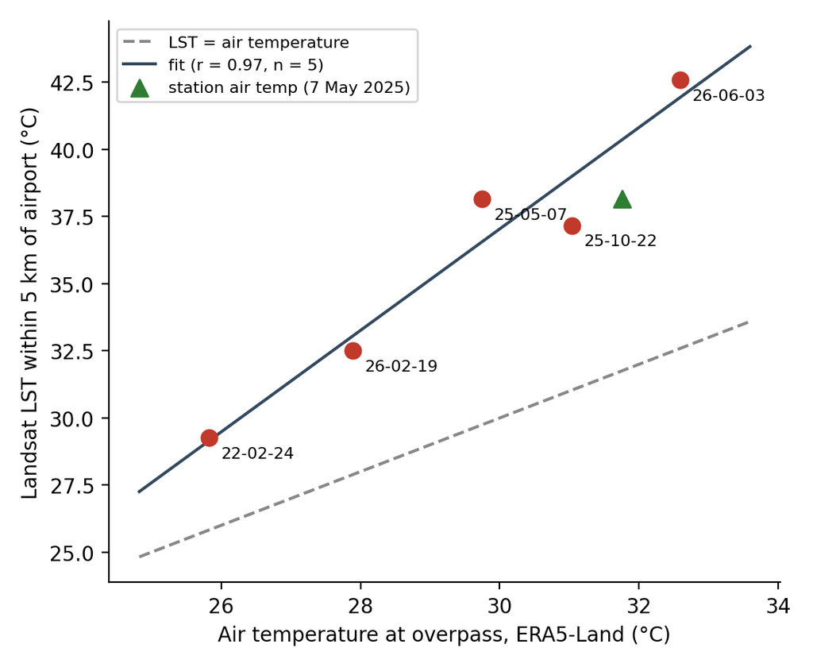

Landsat surface temperature within 5 km of the airport against reanalysis air temperature at overpass time.

For 7 May 2025 a NOAA station reading is also available: 31.8 °C of air against 38.2 °C of surface temperature.

## Reproduce it

Thirteen scripts run in order, from preprocessing to the validation figure, and a short changelog records the seven bugs I found and fixed in the first version of the pipeline, including a cloud-contamination error that had inflated one date's heat island to 11 °C. The repository is at github.com/fmad121581-hub/uhi-dhaka.

Data: Landsat Collection 2 Level-2 (USGS, via Microsoft Planetary Computer), ESA WorldCover, WorldPop, GADM ward boundaries, ERA5-Land through Open-Meteo, NOAA ISD. Analysis in Python with rasterio, geopandas, esda and scikit-learn.